# Who Is Dissatisfied With Their Finances?

A weighted analysis of the 2024 General Social Survey

Author

Adeel Manaf

Published

2 October 2026

## Executive summary

In 2024, 31% of U.S. adults (95% CI 28% to 33%) were not satisfied at all with their financial situation, and only 23% were pretty well satisfied. This report asks which adults were most and least satisfied, and which characteristics are still linked to dissatisfaction once income is taken into account. Age, education, work status and marital status all remained linked to dissatisfaction even among adults with the same income. Three findings stand out.

**1. Income makes the biggest difference at the top.** Adults with family incomes under $30k and $30k-$59k were about equally likely to be not satisfied at all (43.1% and 42.5%), and the share fell to 12.8% at $110k or more. At the same age, education, work status and marital status, adults with $110k or more had a quarter of the odds of being not satisfied at all (OR 0.25, 95% CI 0.16 to 0.39).

*Why it matters:* households earning $30k-$59k were as dissatisfied as those earning less, so support aimed only at the lowest incomes would miss a group that is struggling just as much.

**2. Retirees are far less dissatisfied than workers, even at the same income.** Only 14.9% of retirees were not satisfied at all, compared with 30.6% of full-time workers. At the same age, education, marital status and income, retirees had about a third of the odds of full-time workers of being not satisfied at all (OR 0.33, 95% CI 0.22 to 0.50), and their advantage grew, rather than shrank, once income was held constant.

*Why it matters:* financial wellbeing is not only about current income. The retiree result fits the idea that financial security, such as pensions, Social Security and savings, also matters. The GSS doesn’t measure these directly, so this is a likely explanation, not a proven one.

**3. Divorced and separated adults are much more likely to be dissatisfied.** Among divorced or separated adults, 46.3% were not satisfied at all, twice the share of married adults (22.7%). At the same age, education, work status and income, they had about 2.3 times the odds of married adults (OR 2.29, 95% CI 1.70 to 3.08).

*Why it matters:* support for financial wellbeing could be aimed at life events such as divorce and separation, not only at low income. These results show associations, not causes: divorce can strain finances, but money worries can also contribute to divorce.

*About this analysis:* 3,309 adults from the main sample of the 2024 General Social Survey, weighted to represent U.S. adults, analyzed with design-based 95% confidence intervals, Rao-Scott tests and weighted logistic regression. See Limitations for what these results can and can’t show.

## Methods

**Data.** The 2024 General Social Survey (GSS) cross-section from NORC at the University of Chicago (Release 3a), a national survey of U.S. adults. The analysis uses the 3,309 respondents in the main sample. The 677 respondents from NORC’s AmeriSpeak oversample are used only in a sensitivity check (see Limitations).

**Outcome.** Respondents were asked whether they were pretty well satisfied, more or less satisfied, or not satisfied at all with their present financial situation (GSS variable SATFIN). The regression models compare “not satisfied at all” with the other two answers.

**Characteristics.** Age (18-29, 30-44, 45-64, 65+), highest degree (five groups), work status (full time, part time, unemployed, retired, and other, which includes people temporarily off work, in school or keeping house), marital status (married, widowed, divorced or separated, never married) and family income (four bands, plus a “Not reported” group for the 1 in 10 respondents who didn’t give their income). All five were asked on all three GSS ballots. Full definitions are in the [data dictionary](https://github.com/adeelmanaf43/gss-2024-weighted-analysis/blob/main/data_dictionary.md).

**Weights and survey design.** All estimates use NORC’s nonresponse-adjusted weight (WTSSNRPS), which matches the sample to Census population figures, together with the survey’s strata (VSTRAT) and clusters (VPSU). Taking the clusters and weights into account makes confidence intervals wider, and more honest, than treating the sample as a simple random sample.

**Analysis.** Weighted percentages with 95% confidence intervals; Rao-Scott chi-square tests, the survey version of the chi-square test, for differences between groups; and weighted logistic regression (svyglm, quasibinomial family) of being not satisfied at all. The model was fitted once without and once with income, on the same 3,173 respondents who answered every question, and its results are reported as odds ratios with 95% confidence intervals.

**Software.** R 4.2.1, with the survey, srvyr, gtsummary and ggplot2 packages; package versions are recorded with renv. All code is on [GitHub](https://github.com/adeelmanaf43/gss-2024-weighted-analysis).

## Results

### Overall satisfaction

Table 1 shows the share of U.S. adults giving each answer. Weighting changed the shares by up to 2.4 percentage points: before weighting, the people who answered were slightly more dissatisfied than U.S. adults as a whole. Including the AmeriSpeak oversample (“all cases”) changed every estimate by less than 1 point.

Table 1. Satisfaction with financial situation, U.S. adults, 2024: percent (95% CI)

| Satisfaction with financial situation | Unweighted | Weighted, main sample | Weighted, all cases |
| --- | --- | --- | --- |
| Pretty well satisfied | 23.5 (22.1 to 25.0) | 22.7 (20.2 to 25.4) | 22.1 (19.6 to 24.9) |
| More or less satisfied | 44.2 (42.6 to 45.9) | 46.6 (44.0 to 49.3) | 47.4 (44.7 to 50.1) |
| Not satisfied at all | 32.2 (30.7 to 33.9) | 30.7 (28.2 to 33.2) | 30.5 (27.4 to 33.7) |

### Differences between groups

Every characteristic was linked to financial satisfaction (Rao-Scott tests, all p < 0.001; Table 2). The charts below show the share not satisfied at all in each group, with 95% confidence intervals; the gray line marks all U.S. adults. Where two groups’ intervals don’t overlap, the difference between them is clear.

**Table 2. Financial satisfaction by group, U.S. adults, 2024**

| **Group** | **Satisfaction with financial situation** **Pretty well satisfied**<sup>1</sup> | **Satisfaction with financial situation** **More or less satisfied**<sup>1</sup> | **Satisfaction with financial situation** **Not satisfied at all**<sup>1</sup> | **p-value**<sup>2</sup> |  |
| --- | --- | --- | --- | --- | --- |
| Age |  |  |  |  | <0.001 |
| 18-29 | 16.6% | 51.9% | 31.5% |  |  |
| 30-44 | 18.5% | 44.1% | 37.4% |  |  |
| 45-64 | 22.1% | 46.1% | 31.9% |  |  |
| 65+ | 35.1% | 45.9% | 19.0% |  |  |
| Education |  |  |  | <0.001 |  |
| Less than high school | 13.3% | 44.2% | 42.5% |  |  |
| High school | 15.6% | 49.4% | 35.0% |  |  |
| Associate/junior college | 27.4% | 38.6% | 34.0% |  |  |
| Bachelor's | 29.5% | 46.7% | 23.8% |  |  |
| Graduate | 41.6% | 43.6% | 14.8% |  |  |
| Work status |  |  |  | <0.001 |  |
| Full time | 20.5% | 48.8% | 30.6% |  |  |
| Part time | 18.1% | 46.0% | 35.9% |  |  |
| Unemployed | 8.7% | 40.1% | 51.2% |  |  |
| Retired | 36.5% | 48.6% | 14.9% |  |  |
| Other | 20.5% | 40.8% | 38.8% |  |  |
| Marital status |  |  |  | <0.001 |  |
| Married | 29.1% | 48.2% | 22.7% |  |  |
| Widowed | 27.6% | 43.6% | 28.8% |  |  |
| Divorced or separated | 14.2% | 39.4% | 46.3% |  |  |
| Never married | 14.8% | 47.6% | 37.6% |  |  |
| Family income |  |  |  | <0.001 |  |
| Under $30k | 14.5% | 42.4% | 43.1% |  |  |
| $30k-$59k | 12.9% | 44.6% | 42.5% |  |  |
| $60k-$109k | 18.3% | 50.5% | 31.2% |  |  |
| $110k+ | 38.8% | 48.4% | 12.8% |  |  |
| Not reported | 19.9% | 44.6% | 35.5% |  |  |

Source: 2024 General Social Survey (NORC), main sample.  
<sup>1</sup> Weighted row percentages  
<sup>2</sup> chi-squared test with Rao & Scott’s second-order correction

**Age**

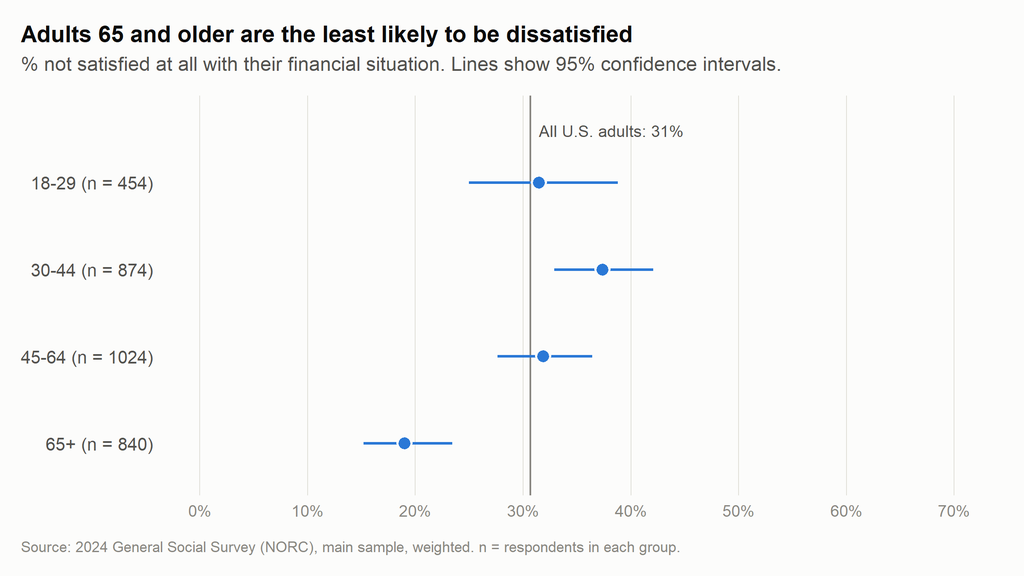

Adults aged 65 and older were clearly the least dissatisfied (19.0%). The three younger groups overlap, so they don’t clearly differ from each other.

**Education**

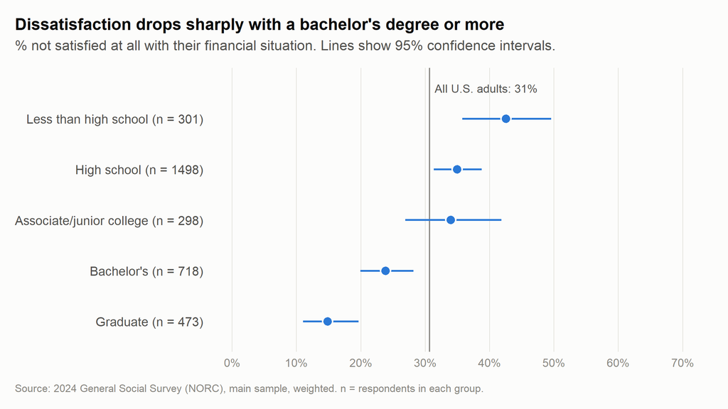

Dissatisfaction fell from 42.5% among adults without a high school diploma to 14.8% among those with a graduate degree. The clear drops come with a bachelor’s degree and a graduate degree.

**Work status**

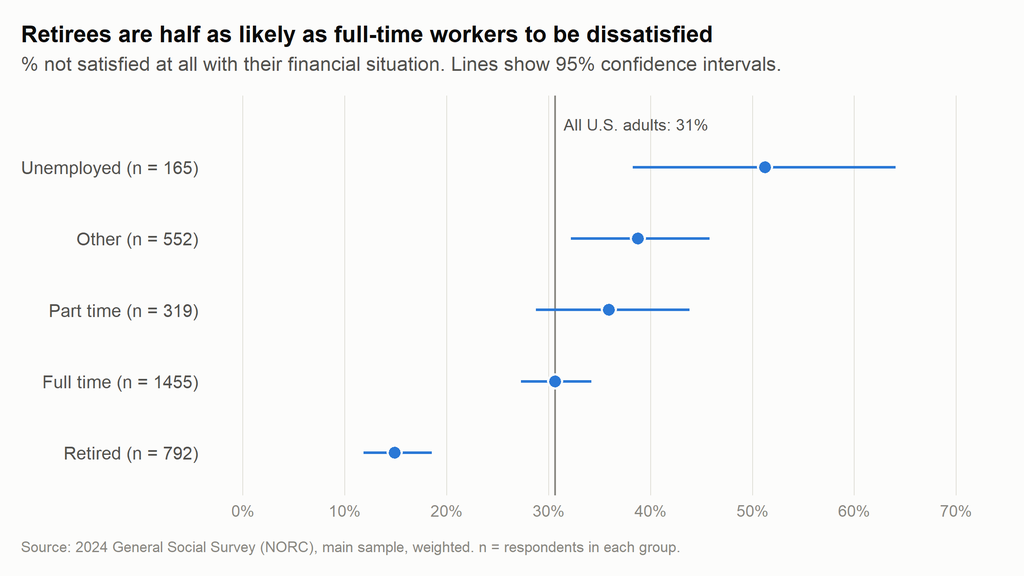

Retirees (14.9%) were half as likely as full-time workers (30.6%) to be not satisfied at all. Unemployed adults had the highest share (51.2%), but it is based on only 165 respondents and is imprecise.

**Marital status**

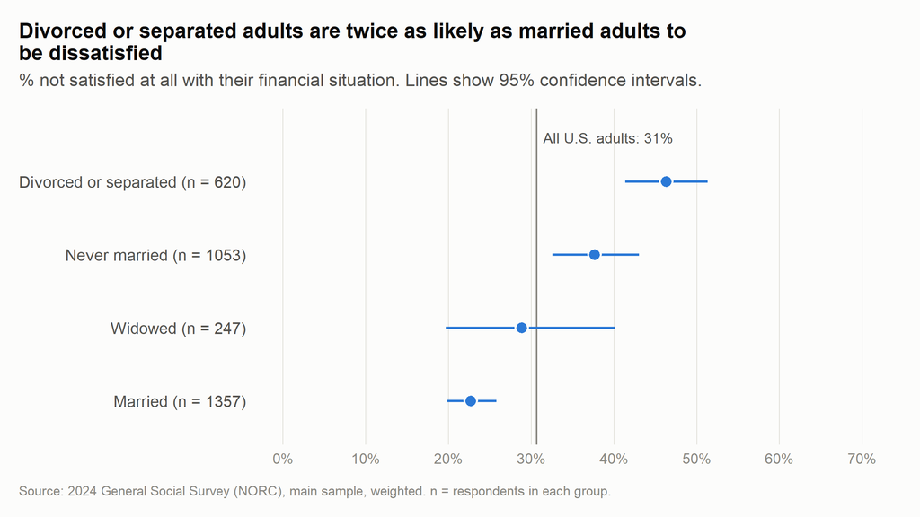

Divorced or separated adults (46.3%) were twice as likely as married adults (22.7%) to be not satisfied at all. The estimate for widowed adults is too uncertain to interpret.

**Family income**

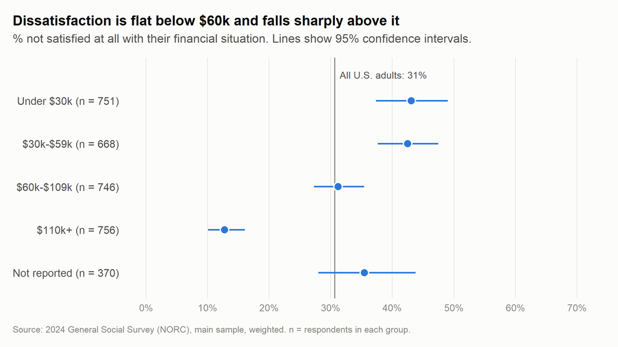

Dissatisfaction was about the same in the two lowest income bands (43.1% and 42.5%), then fell to 31.2% at $60k-$109k and 12.8% at $110k or more.

### What remains once income is held constant

Table 3 shows two weighted logistic regression models of being not satisfied at all: one with age, education, work status and marital status, and one that adds family income. Both use the same 3,173 respondents, so any change between the two columns comes only from holding income constant. An odds ratio (OR) above 1 means higher odds of being not satisfied at all than the reference group (shown with a dash); below 1 means lower odds.

All four characteristics remained linked to dissatisfaction once income was held constant (overall tests: age p = 0.006, education p = 0.011, work status p < 0.001, marital status p < 0.001). Comparing adults who are the same on everything else in the model:

- **Work status.** Retirees had about a third of the odds of full-time workers (OR 0.33, 95% CI 0.22 to 0.50). Unemployed adults no longer clearly differed from full-time workers (OR 1.66, 95% CI 0.94 to 2.95), though this estimate is imprecise.
- **Marital status.** Divorced or separated adults had about 2.3 times the odds of married adults (OR 2.29, 95% CI 1.70 to 3.08), and never-married adults about 1.4 times (OR 1.41, 95% CI 1.05 to 1.91).
- **Education.** Adults with a graduate degree had about half the odds of adults without a high school diploma (OR 0.48, 95% CI 0.30 to 0.78). The difference for a bachelor’s degree was no longer clear once income was added (OR 0.74, 95% CI 0.46 to 1.18), so much of education’s link to satisfaction runs through income.
- **Income.** Adults with $110k or more had a quarter of the odds of those with under $30k (OR 0.25, 95% CI 0.16 to 0.39); the other income bands didn’t clearly differ from under $30k.
- **Age.** Adults aged 30-44 had about twice the odds of adults aged 18-29 (OR 2.01, 95% CI 1.34 to 3.01). Adults aged 65+, the least dissatisfied age group in the charts, no longer clearly differed (OR 1.30, 95% CI 0.75 to 2.27): most of them are retired, so the model credits their advantage to retirement rather than age. Because age and retirement overlap so much, this is the most likely reading, not a proven one.

**Table 3. Odds of being not satisfied at all with one’s financial situation, U.S. adults, 2024**

| **Characteristic** | **Without income** **OR**<sup>1</sup> | **Without income** **95% CI**<sup>1</sup> | **Without income** **p-value** | **With income** **OR**<sup>1</sup> | **With income** **95% CI**<sup>1</sup> | **With income** **p-value** |
| --- | --- | --- | --- | --- | --- | --- |
| Age |  |  |  |  |  |  |
| 18-29 | — | — |  | — | — |  |
| 30-44 | 1.88 | 1.24, 2.86 | 0.003 | 2.01 | 1.34, 3.01 | 0.001 |
| 45-64 | 1.49 | 0.97, 2.28 | 0.067 | 1.65 | 1.09, 2.50 | 0.019 |
| 65+ | 1.22 | 0.69, 2.17 | 0.5 | 1.30 | 0.75, 2.27 | 0.3 |
| Education |  |  |  |  |  |  |
| Less than high school | — | — |  | — | — |  |
| High school | 0.83 | 0.59, 1.18 | 0.3 | 0.97 | 0.69, 1.38 | 0.9 |
| Associate/junior college | 0.74 | 0.48, 1.15 | 0.2 | 0.90 | 0.55, 1.48 | 0.7 |
| Bachelor's | 0.48 | 0.31, 0.76 | 0.002 | 0.74 | 0.46, 1.18 | 0.2 |
| Graduate | 0.31 | 0.19, 0.50 | <0.001 | 0.48 | 0.30, 0.78 | 0.004 |
| Work status |  |  |  |  |  |  |
| Full time | — | — |  | — | — |  |
| Part time | 1.19 | 0.81, 1.74 | 0.4 | 1.02 | 0.71, 1.48 | >0.9 |
| Unemployed | 1.84 | 1.04, 3.25 | 0.036 | 1.66 | 0.94, 2.95 | 0.080 |
| Retired | 0.41 | 0.27, 0.62 | <0.001 | 0.33 | 0.22, 0.50 | <0.001 |
| Other | 1.20 | 0.88, 1.65 | 0.2 | 1.00 | 0.71, 1.42 | >0.9 |
| Marital status |  |  |  |  |  |  |
| Married | — | — |  | — | — |  |
| Widowed | 1.92 | 1.09, 3.39 | 0.025 | 1.53 | 0.86, 2.75 | 0.15 |
| Divorced or separated | 2.98 | 2.23, 3.98 | <0.001 | 2.29 | 1.70, 3.08 | <0.001 |
| Never married | 1.74 | 1.30, 2.32 | <0.001 | 1.41 | 1.05, 1.91 | 0.025 |
| Family income |  |  |  |  |  |  |
| Under $30k |  |  |  | — | — |  |
| $30k-$59k |  |  |  | 1.08 | 0.75, 1.56 | 0.7 |
| $60k-$109k |  |  |  | 0.73 | 0.51, 1.06 | 0.094 |
| $110k+ |  |  |  | 0.25 | 0.16, 0.39 | <0.001 |
| Not reported |  |  |  | 1.05 | 0.70, 1.57 | 0.8 |

Weighted logistic regression (svyglm, quasibinomial family). OR = odds ratio; an OR above 1 means higher odds of dissatisfaction than the reference group (shown as a dash). Source: 2024 General Social Survey (NORC), main sample, n = 3,173.  
<sup>1</sup> OR = Odds Ratio, CI = Confidence Interval

## Limitations

**Survey mode.** The 2024 GSS was collected in several ways: about half of the main-sample respondents answered online, about a third in person, and the rest by phone or a mix of modes. People can answer the same question differently depending on how it’s asked; on the web, for example, opinion questions like this one don’t offer a “Don’t know” option. NORC advises analyzing the sample as a whole rather than by mode, and its weights are designed only for the whole sample. This analysis follows that advice and never splits results by mode, but its estimates still reflect this mix of modes.

**Comparing with earlier years.** The GSS changed its methods during the COVID-19 pandemic: it was collected mostly online in 2021 and in a mix of modes from 2022. This analysis uses only 2024 data and makes no claims about change over time. Anyone comparing these results with GSS figures from before 2020 should keep NORC’s caution in mind:

> Changes in opinions, attitudes, and behaviors observed in 2021, 2022, and 2024 relative to historical trends may be due to actual change in concept over time and/or may have resulted from methodological changes made to the survey methodology during the COVID-19 global pandemic.

**Who answered: weights and nonresponse.** Only 44.6% of the people sampled for the main survey took part. The weight used here (WTSSNRPS) adjusts for this nonresponse and matches the sample to Census population figures, but weights can only correct for differences in known characteristics, such as age and region, not for unknown ones. Weighting changed the estimates by up to 2.4 percentage points. The 677 respondents from NORC’s AmeriSpeak oversample were left out of the main analysis: all of them answered online, and their response rate was 3.5% once panel recruitment is counted. Including them changed the estimates by less than 1 point.

**Questions asked of only part of the sample.** The GSS splits respondents into three ballots, and most of its core questions go to only two of them. This analysis uses only questions asked on all three ballots, and checks that each ballot has answers for every variable. The cost is that some relevant measures, such as home ownership and self-rated health, were asked on only two ballots and were left out.

**Missing answers.** About 1 in 10 respondents didn’t report their family income. Rather than dropping them, this analysis keeps them as a “Not reported” income group; this is a simple fix, not a full statistical method for missing data. The model uses 3,173 of the 3,309 main-sample respondents (96%); the rest skipped at least one question, most often their age. If people who skip questions differ from those who answer, the estimates could be slightly off.

**Small groups.** Some groups have few respondents, so their estimates are imprecise. Unemployed adults (165 respondents) have a 95% confidence interval of 38% to 64%, and widowed adults (247) of 20% to 40%. These groups shouldn’t be ranked against similar groups; in the model, the difference for unemployed adults is also no longer clear (OR 1.66, 95% CI 0.94 to 2.95).

**Associations, not causes.** The GSS is a one-time survey, so these results show which groups are more or less dissatisfied, not what causes dissatisfaction. Divorce may lead to money worries, for example, but money worries can also contribute to divorce. Age and retirement also overlap so much that the model can’t fully separate them: that the advantage of adults aged 65+ comes from retirement rather than age is the most likely reading, not a proven one.

**How things were measured.** Income is last year’s total family income, reported in bands. It doesn’t capture savings, debts, household size or local living costs, and the top band ($110k+) includes all higher incomes. The outcome compares “not satisfied at all” with the other two answers, and a different split might give somewhat different results. Some groups also combine different situations: “Other” work status includes people temporarily off work, in school or keeping house, and divorced and separated adults are combined into one group.

## Next steps

- **Use all three satisfaction answers.** Fit an ordinal model (`svyolr()` in the survey package) to check that the results don’t depend on how the outcome was split.
- **Add wealth and health measures.** Analyze ballots A and B on their own, adding home ownership and self-rated health, to test the “security” idea suggested by the retiree results.
- **Check results by mode** once NORC releases mode-specific weights, which it plans for future releases.
- **Compare with the 2022 GSS,** keeping NORC’s caution about method changes in mind.

## Data citation

Davern, Michael; Bautista, Rene; Freese, Jeremy; Herd, Pamela; and Morgan, Stephen L.; General Social Survey 1972-2024. [Machine-readable data file]. Principal Investigator, Michael Davern; Co-Principal Investigators, Rene Bautista, Jeremy Freese, Pamela Herd, and Stephen L. Morgan. NORC ed. Chicago, 2026. 1 datafile (Release 3a) and 1 codebook (2024 Release 3a).